# Project 2

Benjamin Hendrick

February 14, 2016

# Part A: Data Pre-processing and Model Evaluation

## Problem 1

The formula for *min-max normalization* from the text is:

$$v_{i}' = \frac{v_{i}- min_{A}}{max_{A} - min_{A}}(newMax_{A} - newMin_{A}) + newMin_{A}$$

The R function for this formula may be written as:

```r
minMaxNorm <- function (train,test,l,u){
  normalized <- (test-min(train))/(max(train)-min(train))*(u-l)+l # Patro and Kumar
  return(normalized)
}
```

where `test` is the data being normalized, `train` is the data minimized and maximized, `l` is the new lower bound, and `u` is the new upper bound. In some cases `train` and `test` may be the same data.

The formula for *z-score normalization* from the text is:

$$v_{i}' = \frac{v_{i} - \bar{A}}{\sigma_{A}}$$

The R function for this formula may be written as:

```r
zScoreNorm <- function (train,test,type){
  if (type == 1) {
    z <- (test-mean(train))/sd(train)
  }
  if (type == 2) {
    z <- (test - mean(train)) / (length(test)^-1 * sum(abs(test-mean(train))))
  }
  return(z)
}
```

where `test` is the data being normalized,`train` is the data used to evalue `mean` and `sd`, and `type` is the type of z-score normalization being selection (1 uses standard deviation and 2 uses mean absolute deviation.)

## Problem 2

Load the data from the text.

```r
data <- c(200,300,400,600,1000)
```

### Part A

Normalize the data with min-max normalization with $min=0$ and $max=1$.

```r
a <- minMaxNorm(data,data,0,1)
```

### Part B

Normalize the data with z-score normalization using standard deviation.

```r
b <- zScoreNorm(data,data,1)
```

### Part C

Normalize the data with z-score normalization using mean absolute deviation instead of standard deviation.

```r
c <- zScoreNorm(data,data,2)
```

The normalized data, using all three methods in parts A, B, and C, may be summarized in the following table.

| Orignal Data | Min-Max Normalization | Z-Score Normalization (s.d.) | Z-Score Normalization (m.a.d.) |
| --- | --- | --- | --- |
| 200 | 0 | -0.9486833 | -1.25 |
| 300 | 0.125 | -0.6324555 | -0.8333333 |
| 400 | 0.25 | -0.3162278 | -0.4166667 |
| 600 | 0.5 | 0.3162278 | 0.4166667 |
| 1000 | 1 | 1.5811388 | 2.0833333 |

## Problem 3

Load the data from the web:

```r
iris <- read.csv("/var/folders/6j/_n_8wtg912559sqd775wfctw0000gn/T//Rtmpmv0LxE/data1b074f253bfa", header=FALSE)
data <- c(1.6, 2.8, 3.72,4.97)
```

### Part A

Use the `minMaxNorm` function from Problem 1. Set `iris$V3` (pedal length) as the training data and `data` as the testing data. Set the lower and upper bounds to -1 and 1, repsectively.

```r
a <- minMaxNorm(iris$V3,data,-1,1)
```

### Part B

Use the `zScoreNorm` function from Problem 1. Set `iris$V3` (pedal length) as the training data and `data` as the testing data. Set the function type to `1` to use standard deviation.

```r
b <- zScoreNorm(iris$V3,data,1)
```

### Part C

Use the `zScoreNorm` function from Problem 1. Set `iris$V3` (pedal length) as the training data and `data` as the testing data. Set the function type to `2` to use mean absolute deviation.

```r
c <- zScoreNorm(iris$V3,data,2)
```

The normalized data, using all three methods in parts A, B, and C, may be summarized in the following table.

| Orignal Data | Min-Max Normalization | Z-Score Normalization (s.d.) | Z-Score Normalization (m.a.d.) |
| --- | --- | --- | --- |
| 1.6 | -0.7966102 | -1.2234424 | -1.9771027 |
| 2.8 | -0.3898305 | -0.5433323 | -0.8780339 |
| 3.72 | -0.0779661 | -0.0219147 | -0.0354144 |
| 4.97 | 0.3457627 | 0.6865333 | 1.1094489 |

### Problem 4

```r
predictionEvaluate <- function(yPred, yTrue, thresh){
  for (i in 1:length(yPred)) {
    if (1-yPred[i] < thresh) {
      yPred[i] <- 1
    } else {
      yPred[i] <- 0
    }
  }

  tp <- 0
  for (i in 1:length(yTrue)) {
    if (yTrue[i] == 1) {
      if(yTrue[i] == yPred[i]){
        tp <- tp + 1
      }
    }
  }

  tn <- 0
  for (i in 1:length(yTrue)) {
    if (yTrue[i] == 0) {
      if(yTrue[i] == yPred[i]){
        tn <- tn + 1
      }
    }
  }

  fp <- 0
  for (i in 1:length(yTrue)) {
    if (yTrue[i] == 1) {
      if(yTrue[i] != yPred[i]){
        fp <- fp + 1
      }
    }
  }

  fn <- 0
  for (i in 1:length(yTrue)) {
    if (yTrue[i] == 0) {
      if(yTrue[i] != yPred[i]){
        fn <- fn + 1
      }
    }
  }

  tpr <- tp/(tp+fp)
  tnr <- tn/(fp+tn)
  sens <- tp/(tp+tn)
  spec <- tn/(fp+tn)
  prec <- tp/(tp+fp)
  rec <- tp/(tp+fn)
  acc <- (tp+tn)/(tp+fp+fn+tn)

  results <- list()
  results$tp <- tp
  results$tn <- tn
  results$fp <- fp
  results$fn <- fn
  results$tpr <- tpr
  results$tnr <- tnr
  results$sens <- sens
  results$spec <- spec
  results$prec <- prec
  results$rec <- rec
  results$acc <- acc
  return (results)
}
```

### Problem 5

Load the $Y_{True}$ and $Y_{Pred}$ into `R`.

```r
yPred <- c(0.98,0.92,0.85,0.77,0.71,0.64,0.50,0.39,0.34,0.31)
yTrue <- c(1,0,1,1,0,0,1,0,1,0)
```

Use the `predictionEvalute` function from Problem 4 to evaluate the data.

```r
yEval <- predictionEvaluate(yPred,yTrue,0.5)
```

The following table shows the results of the evalutation.

[output not shown]

### Problem 6

```r
sens.list <- c()
thresh.list <- c()
for (i in 1:10) {
  tmp <- predictionEvaluate(yPred, yTrue, 0.01*i)
  sens.list[i] <- tmp$sens
  thresh.list[i] <- 0.1*i
}
```

Plot the ROC curve where `x` is threshold and `y` is sensativity.

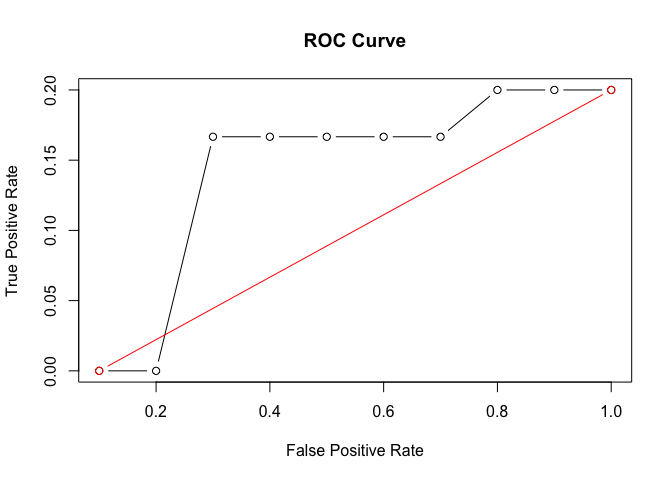

*Figure: The ROC curve for the $Y$ data in Problem 5.*

```r
plot(thresh.list, sens.list,
     xlab = "False Positive Rate",
     ylab = "True Positive Rate",
     main = "ROC Curve",
     type = "b")
lines(x=c(0.1,1), y=c(0,0.2),col="red",type="b")
```

### Problem 7

Load the error arrays $M_{1}$ and $M_{2}$ into `R`.

```r
m1 <- c(30.5, 32.2, 20.7, 20.6, 31.0, 41.0, 27.7, 26.0, 21.5, 26.0)
m2 <- c(22.4, 14.5, 22.4, 19.6, 20.7, 20.4, 22.1, 19.4, 16.2, 35.0)
```

Perform a two sided t-test to evalute the difference between the means of the errors with 99% confidence.

```r
t.test(m1, m2, alternative = "two.sided", mu = 0, conf.level = 0.99)
```

```
##
##  Welch Two Sample t-test
##
## data:  m1 and m2
## t = 2.4376, df = 17.649, p-value = 0.02561
## alternative hypothesis: true difference in means is not equal to 0
## 99 percent confidence interval:
##  -1.184208 14.084208
## sample estimates:
## mean of x mean of y
##     27.72     21.27
```

# Part B: Classification I

## Problem 1

Load the nodes and splits into `R` as arrays.

```r
N <- c(100,50,60)
N11 <- c(62,8,0)
N12 <- c(38,42,60)
N21 <- c(65,20,0)
N22 <- c(21,19,20)
N23 <- c(14,11,40)
```

### Part A

Compute the gini indexes for $N_{1,1}$ and $N_{1,2}$. These are represented in `R` as `gini.N11` and `gini.N12`, respectively.

```r
gini.N11 <- 1 - (N11[1]/(N11[1]+N[1]))^2 - (N11[2]/(N11[2]+N[2]))^2 - (N11[3]/(N11[3]+N[3]))^2
gini.N12 <- 1 - (N12[1]/(N[1]+N12[1]))^2 - (N12[2]/(N[2]+N12[2]))^2 - (N12[3]/(N[3]+N12[3]))^2
```

The gini index for node $N_{1,1}$ is 0.8345035. The gini index for node $N_{1,2}$ is 0.4657635.

### Part B

I would select node $N_{1,2}$ because it has the smallest gini index.

### Part C

Compute the entropy for $N_{1,1}$ and $N_{1,2}$. These are represented in `R` as `ent.N11` and `ent.N12`, respectively.

```r
ent.N11 <- -sum(N11)/sum(N11,N) * log(sum(N11)/sum(N11,N),base = 2) - sum(N)/sum(N11,N) * log(sum(N)/sum(N11,N),base = 2)

ent.N12 <- -sum(N12)/sum(N12,N) * log(sum(N12)/sum(N12,N),base = 2) - sum(N)/sum(N12,N) * log(sum(N)/sum(N12,N),base = 2)
```

The entropy for node $N_{1,1}$ is 0.8112781. The entropy for node $N_{1,2}$ is 0.9709506.

### Part D

I would select node $N_{1,1}$ because it has the smallest entropy.

## Problem 2

### Part A

```r
spam <- read.csv("/var/folders/6j/_n_8wtg912559sqd775wfctw0000gn/T//Rtmpmv0LxE/data1b071254b98b")
spam <- spam[,-c(1,2,6,19,20,11)]
```

### Part B

Use the `createDataPartition` function from the `caret` package to split the data into a 80% training data and 20% testing data.

```r
library(caret)
set.seed(100)
rows <- createDataPartition(spam$name, p = 0.8, list = FALSE)
spamTrain <- spam[rows,]
spamTest <- spam[-rows,]
```

### Part C

Use the `rpart` function in the `rpart` library to fit the data into a classification tree. The fitted model is called `spam.fit`.

```r
library(rpart)
spam.fit <- rpart(spam~.,
                  data = spamTrain,
                  method = "class")
```

### Part D

Use the `plot` function to plot the classification tree `spam.fit`.

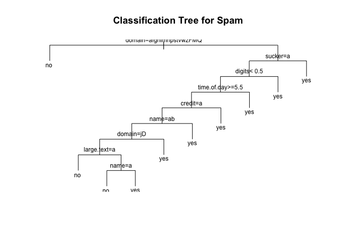

```r
plot(spam.fit, uniform=TRUE,
     main="Classification Tree for Spam")
text(spam.fit,cex=0.75)
```

There are 10 terminal leaves. There are 19 nodes.

Print the tree as well.

```r
print(spam.fit)
```

```
## n= 1737
##
## node), split, n, loss, yval, (yprob)
##       * denotes terminal node
##
##   1) root 1737 569 no (0.67242372 0.32757628)
##     2) domain=at,ca,ch,cn,cz,de,edu,gov,hu,il,is,it,kw,org,se,uk 954  20 no (0.97903564 0.02096436) *
##     3) domain=bak,by,c,co,com,fr,hkd,info,jp,kr,lt,lv,net,pin,pl,pt,rdp,ro,sk,tsp,us 783 234 yes (0.29885057 0.70114943)
##       6) sucker=no 612 231 yes (0.37745098 0.62254902)
##        12) digits< 0.5 472 213 yes (0.45127119 0.54872881)
##          24) time.of.day>=5.5 383 185 no (0.51697128 0.48302872)
##            48) credit=no 348 154 no (0.55747126 0.44252874)
##              96) name=empty,name 282 109 no (0.61347518 0.38652482)
##               192) domain=com,net 270  98 no (0.63703704 0.36296296)
##                 384) large.text=no 209  65 no (0.68899522 0.31100478) *
##                 385) large.text=yes 61  28 yes (0.45901639 0.54098361)
##                   770) name=empty 26   8 no (0.69230769 0.30769231) *
##                   771) name=name 35  10 yes (0.28571429 0.71428571) *
##               193) domain=by,c,info,lt,pin,pl,ro,us 12   1 yes (0.08333333 0.91666667) *
##              97) name=single 66  21 yes (0.31818182 0.68181818) *
##            49) credit=yes 35   4 yes (0.11428571 0.88571429) *
##          25) time.of.day< 5.5 89  15 yes (0.16853933 0.83146067) *
##        13) digits>=0.5 140  18 yes (0.12857143 0.87142857) *
##       7) sucker=yes 171   3 yes (0.01754386 0.98245614) *
```

### Part E

We can find the accuracy and error from the confusion matri using the `confusionMatrix` function from the `caret` package. The AUC can be found using the `auc` function in `AUC` package.

```r
library(AUC)
spam.fit.Train <- predict(spam.fit,spamTrain,"class")
spam.fit.Test <- predict(spam.fit,spamTest,"class")

train.cm <- confusionMatrix(data=spam.fit.Train,
                            reference=spamTrain$spam,
                            positive=c("yes"))
test.cm <- confusionMatrix(data=spam.fit.Test,
                           reference = spamTest$spam,
                           positive=c("yes"))

train.auc <- auc(sensitivity(spam.fit.Train, spamTrain$spam))
test.auc <- auc(sensitivity(spam.fit.Test, spamTest$spam))
```

The training and testing accuracies, errors, and AUCs are shown in the following table. The confusion matrix uses a threshold of 0.5 by default.

| Set | Accuracy | Error | AUC |
| --- | --- | --- | --- |
| Training | 0.9050086 | 0.0949914 | 0.7608693 |
| Testing | 0.8847926 | 0.1152074 | 0.7440926 |

### Part F

The tree is pruned with the `prune` function in the `class` package. This is done with a `cp` value of 0.015 and 0.2. The same methods of finind accuracy, error, and AUC from Part E are used in the code below.

```r
spam.pfit <- prune(spam.fit, cp= 0.015)

spam.pfit.Train <- predict(spam.pfit,spamTrain,"class")
spam.pfit.Test <- predict(spam.pfit,spamTest,"class")

ptrain.cm <- confusionMatrix(data=spam.pfit.Train,
                            reference=spamTrain$spam,
                            positive=c("yes"))
ptest.cm <- confusionMatrix(data=spam.pfit.Test,
                           reference = spamTest$spam,
                           positive=c("yes"))

ptrain.auc <- auc(sensitivity(spam.pfit.Train, spamTrain$spam))
ptest.auc <- auc(sensitivity(spam.pfit.Test, spamTest$spam))

spam.pfit2 <- prune(spam.fit, cp= 0.2)

spam.pfit.Train2 <- predict(spam.pfit2,spamTrain,"class")
spam.pfit.Test2 <- predict(spam.pfit2,spamTest,"class")

ptrain.cm2 <- confusionMatrix(data=spam.pfit.Train2,
                             reference=spamTrain$spam,
                             positive=c("yes"))
ptest.cm2 <- confusionMatrix(data=spam.pfit.Test2,
                            reference = spamTest$spam,
                            positive=c("yes"))

ptrain.auc2 <- auc(sensitivity(spam.pfit.Train2, spamTrain$spam))
ptest.auc2 <- auc(sensitivity(spam.pfit.Test2, spamTest$spam))
```

The training and testing accuracies, errors, and AUCs with different prune `cp` values are shown in the following table. The confusion matrix uses a threshold of 0.5 by default.

| `cp` | Set | Accuracy | Error | AUC |
| --- | --- | --- | --- | --- |
| 0.015 | Training | 0.8963731 | 0.1036269 | 0.7489885 |
| 0.015 | Testing | 0.8525346 | 0.1474654 | 0.7106906 |
| 0.2 | Training | 0.8537709 | 0.1462291 | 0.7573347 |
| 0.2 | Testing | 0.8686636 | 0.1313364 | 0.7693401 |

## Problem 3

### Part A

Load the data into `R` and remove the specified columns.

```r
music <- read.csv("/var/folders/6j/_n_8wtg912559sqd775wfctw0000gn/T//Rtmpmv0LxE/data1b076228f72f")
music <- music[,-c(2,3,4,5)]
```

### Part B

```r
library(caret)
set.seed(100)
musicSplit <- createDataPartition(music$Top10, p = 0.8, list = TRUE, time=10)
```

We can check the distribution of each strification by saving the percentages of ones and zero from each strification into two array. This is done for the testing and training set.

```r
trainDistZero <- c()
trainDistOne <- c()

for (i in 1:10) {
  musicTrain <- music[musicSplit[[i]],]
  trainDistZero[i] <- prop.table(table(musicTrain$Top10))[1]
  trainDistOne[i] <- prop.table(table(musicTrain$Top10))[2]
}

testDistZero <- c()
testDistOne <- c()

for (i in 1:10) {
  musicTest <- music[-musicSplit[[i]],]
  testDistZero[i] <- prop.table(table(musicTest$Top10))[1]
  testDistOne[i] <- prop.table(table(musicTest$Top10))[2]
}
```

The distribution of 10 training data splits are in the following table.

| Split Number | Number of Zeros | Number of Ones |
| --- | --- | --- |
| 1 | 0.8537954 | 0.1462046 |
| 2 | 0.8509901 | 0.1490099 |
| 3 | 0.8536304 | 0.1463696 |
| 4 | 0.8533003 | 0.1466997 |
| 5 | 0.8519802 | 0.1480198 |
| 6 | 0.8514851 | 0.1485149 |
| 7 | 0.8513201 | 0.1486799 |
| 8 | 0.8508251 | 0.1491749 |
| 9 | 0.8523102 | 0.1476898 |
| 10 | 0.8564356 | 0.1435644 |

The distributions in the tables above are essentially the same by a rounding error.

The distribution of 10 testing data splits are in the following table.

| Split Number | Number of Zeros | Number of Ones |
| --- | --- | --- |
| 1 | 0.846103 | 0.153897 |
| 2 | 0.8573316 | 0.1426684 |
| 3 | 0.8467635 | 0.1532365 |
| 4 | 0.8480845 | 0.1519155 |
| 5 | 0.8533686 | 0.1466314 |
| 6 | 0.8553501 | 0.1446499 |
| 7 | 0.8560106 | 0.1439894 |
| 8 | 0.8579921 | 0.1420079 |
| 9 | 0.8520476 | 0.1479524 |
| 10 | 0.835535 | 0.164465 |

The variation in distribution between each split is more evident in the testing data. This is probably because of the smaller split percentage (20%).

### Part C

The KNN model can be fitted using the `knn` function from the `class` package. The following loops find the accuracy, error, and AUC for each of the 10 data splits. The accuracy, error, and AUC are found the same way as in Problem 2. We do this for $k = 1,5,9$.

```r
library(class)
library(ROCR)
kValue = 1
acc <- c()
err <- c()
auc <- c()
for (i in 1:10){
  musicTrain <- music[musicSplit[[i]],]
  musicTest <- music[-musicSplit[[i]],]

  model <- knn(musicTrain[,1:34],
               musicTest[,1:34],
               cl=musicTrain[,35],
               k=kValue)

  knn.cm <- confusionMatrix(data=model,
                              reference = musicTest$Top10,
                              positive=c("1"))
  acc[i] <- knn.cm$overall[[1]]
  err[i] <- 1 - knn.cm$overall[[1]]

  knn.pred <- prediction(as.numeric(model)-1, as.numeric(musicTest$Top10)-1)
  knn.auc <- performance(knn.pred,"auc")
  auc[i] <- knn.auc@y.values[[1]]
}
```

The following table shows the accuracy, error, and AUC for each of KNN fits for the data splits where $k=1$

| Split Number | Accuracy | Error | AUC |
| --- | --- | --- | --- |
| 1 | 0.7668428 | 0.2331572 | 0.5497197 |
| 2 | 0.7760898 | 0.2239102 | 0.5587478 |
| 3 | 0.7747688 | 0.2252312 | 0.5810493 |
| 4 | 0.7655218 | 0.2344782 | 0.5619633 |
| 5 | 0.7813738 | 0.2186262 | 0.5827894 |
| 6 | 0.7846764 | 0.2153236 | 0.5800956 |
| 7 | 0.7965654 | 0.2034346 | 0.5969143 |
| 8 | 0.7760898 | 0.2239102 | 0.5706518 |
| 9 | 0.7754293 | 0.2245707 | 0.5601779 |
| 10 | 0.7840159 | 0.2159841 | 0.5804515 |

```r
library(class)
library(ROCR)
kValue = 5
acc <- c()
err <- c()
auc <- c()
for (i in 1:10){
  musicTrain <- music[musicSplit[[i]],]
  musicTest <- music[-musicSplit[[i]],]

  model <- knn(musicTrain[,1:34],
               musicTest[,1:34],
               cl=musicTrain[,35],
               k=kValue)

  knn.cm <- confusionMatrix(data=model,
                              reference = musicTest$Top10,
                              positive=c("1"))
  acc[i] <- knn.cm$overall[[1]]
  err[i] <- 1 - knn.cm$overall[[1]]

  knn.pred <- prediction(as.numeric(model)-1, as.numeric(musicTest$Top10)-1)
  knn.auc <- performance(knn.pred,"auc")
  auc[i] <- knn.auc@y.values[[1]]
}
```

The following table shows the accuracy, error, and AUC for each of KNN fits for the data splits where $k=5$

| Split Number | Accuracy | Error | AUC |
| --- | --- | --- | --- |
| 1 | 0.830251 | 0.169749 | 0.5397892 |
| 2 | 0.847424 | 0.152576 | 0.5386028 |
| 3 | 0.831572 | 0.168428 | 0.5457495 |
| 4 | 0.8269485 | 0.1730515 | 0.5214445 |
| 5 | 0.8361955 | 0.1638045 | 0.5458957 |
| 6 | 0.84214 | 0.15786 | 0.5453941 |
| 7 | 0.8454425 | 0.1545575 | 0.5472449 |
| 8 | 0.838177 | 0.161823 | 0.5408507 |
| 9 | 0.8414795 | 0.1585205 | 0.556513 |
| 10 | 0.8295905 | 0.1704095 | 0.565792 |

```r
library(class)
library(ROCR)
kValue = 9
acc <- c()
err <- c()
auc <- c()
for (i in 1:10){
  musicTrain <- music[musicSplit[[i]],]
  musicTest <- music[-musicSplit[[i]],]

  model <- knn(musicTrain[,1:34],
               musicTest[,1:34],
               cl=musicTrain[,35],
               k=kValue)

  knn.cm <- confusionMatrix(data=model,
                              reference = musicTest$Top10,
                              positive=c("1"))
  acc[i] <- knn.cm$overall[[1]]
  err[i] <- 1 - knn.cm$overall[[1]]

  knn.pred <- prediction(as.numeric(model)-1, as.numeric(musicTest$Top10)-1)
  knn.auc <- performance(knn.pred,"auc")
  auc[i] <- knn.auc@y.values[[1]]
}
```

The following table shows the accuracy, error, and AUC for each of KNN fits for the data splits where $k=9$

| Split Number | Accuracy | Error | AUC |
| --- | --- | --- | --- |
| 1 | 0.8388375 | 0.1611625 | 0.5237961 |
| 2 | 0.8540291 | 0.1459709 | 0.5212292 |
| 3 | 0.844782 | 0.155218 | 0.5235421 |
| 4 | 0.8401585 | 0.1598415 | 0.5149567 |
| 5 | 0.8480845 | 0.1519155 | 0.5304786 |
| 6 | 0.8513871 | 0.1486129 | 0.5261385 |
| 7 | 0.8533686 | 0.1466314 | 0.5251656 |
| 8 | 0.8454425 | 0.1545575 | 0.5159747 |
| 9 | 0.8507266 | 0.1492734 | 0.5287375 |
| 10 | 0.8348745 | 0.1651255 | 0.5383113 |

### Part D

The decision tree is created in the same way as in Problem 2. The accuracy, error, and AUC are found in the same way as the previous part.

```r
acc <- c()
err <- c()
auc <- c()
for (i in 1:10){
  musicTrain <- music[musicSplit[[i]],]
  musicTest <- music[-musicSplit[[i]],]

  model <- rpart(Top10 ~ .,
                 data = musicTrain,
                 method = "class")
  model.fit <- predict(model,musicTest,"class")
  tree.cm <- confusionMatrix(data=model.fit,
                            reference = musicTest$Top10,
                            positive=c("1"))
  acc[i] <- tree.cm$overall[[1]]
  err[i] <- 1 - tree.cm$overall[[1]]

  tree.pred <- prediction(as.numeric(model.fit)-1, as.numeric(musicTest$Top10)-1)
  tree.auc <- performance(tree.pred,"auc")
  auc[i] <- tree.auc@y.values[[1]]
}
```

The following table shows the accuracy, error, and AUC for each of decision tree models fits for the 10 partition splits.

| Split Number | Accuracy | Error | AUC |
| --- | --- | --- | --- |
| 1 | 0.8579921 | 0.1420079 | 0.5596938 |
| 2 | 0.8586526 | 0.1413474 | 0.5509402 |
| 3 | 0.8527081 | 0.1472919 | 0.5670558 |
| 4 | 0.8480845 | 0.1519155 | 0.5678112 |
| 5 | 0.8579921 | 0.1420079 | 0.5568014 |
| 6 | 0.8626156 | 0.1373844 | 0.5402902 |
| 7 | 0.8652576 | 0.1347424 | 0.5473723 |
| 8 | 0.8652576 | 0.1347424 | 0.5702168 |
| 9 | 0.8560106 | 0.1439894 | 0.5281492 |
| 10 | 0.8467635 | 0.1532365 | 0.5470387 |

The tree is pruned using `cp = 0.2` as a attribute to the `prune` function.

```r
acc <- c()
err <- c()
auc <- c()
for (i in 1:10){
  musicTrain <- music[musicSplit[[i]],]
  musicTest <- music[-musicSplit[[i]],]

  model <- rpart(Top10 ~ .,
                 data = musicTrain,
                 method = "class")
  model.prune <- prune(model, cp= 0.2)
  model.fit <- predict(model.prune,musicTest,"class")
  tree.cm <- confusionMatrix(data=model.fit,
                             reference = musicTest$Top10,
                             positive=c("1"))
  acc[i] <- tree.cm$overall[[1]]
  err[i] <- 1 - tree.cm$overall[[1]]

  tree.pred <- prediction(as.numeric(model.fit)-1, as.numeric(musicTest$Top10)-1)
  tree.auc <- performance(tree.pred,"auc")
  auc[i] <- tree.auc@y.values[[1]]
}
```

The following table shows the accuracy, error, and AUC for each of pruned decision tree models fits for the 10 partition splits.

| Split Number | Accuracy | Error | AUC |
| --- | --- | --- | --- |
| 1 | 0.846103 | 0.153897 | 0.5 |
| 2 | 0.8573316 | 0.1426684 | 0.5 |
| 3 | 0.8467635 | 0.1532365 | 0.5 |
| 4 | 0.8480845 | 0.1519155 | 0.5 |
| 5 | 0.8533686 | 0.1466314 | 0.5 |
| 6 | 0.8553501 | 0.1446499 | 0.5 |
| 7 | 0.8560106 | 0.1439894 | 0.5 |
| 8 | 0.8579921 | 0.1420079 | 0.5 |
| 9 | 0.8520476 | 0.1479524 | 0.5 |
| 10 | 0.835535 | 0.164465 | 0.5 |

### Part E

The inclusion of negative samples would influence the results. The all positive data would would force a positive prediction. Therefore, the predictions may be skewed to a different side (one vs. zero) depending how the prediction formula works.